# The Tidyverse

Now we have a little more - we’ve added the axes and gridmarks, but still not data. What we now have to specify is how we want the data plotted. In the language of ggplot, we need to add a *geom*. An ovious way to do that is as an xy scatterplot, which is specified by `geom_point()`. Having created the base plot, we can now add a new layer, with the scatterplot, as follows:

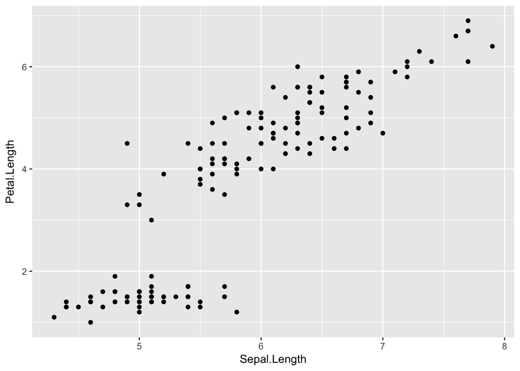

```r
pl2 <-pl1 +
  geom_point()
pl2
```

Finally, remember that we want to show species each plant belongs to. An obvious way would be to differentiate them by color, which we can do by providing an aesthetic for the geom_point layer:

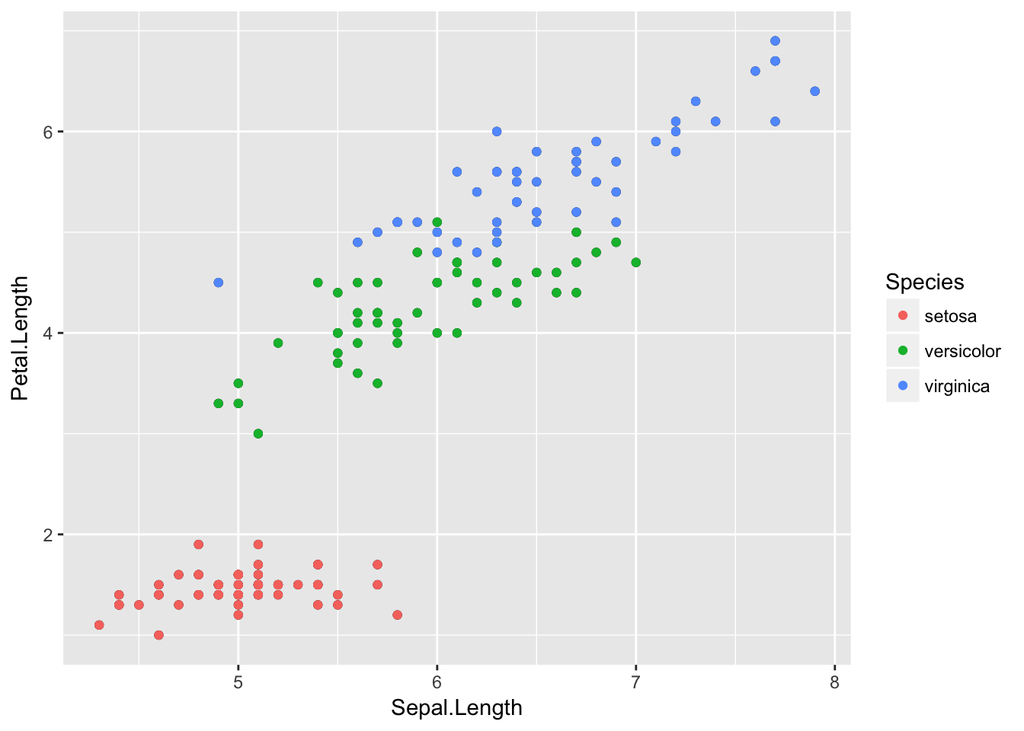

```r
pl3 <- pl2 +
  geom_point(aes(color=Species))
pl3
```

And we now have a complete visualization with which we can (at least qualitatively) answer our original question.

One coding note - we could have done the whole process above with one single statement:

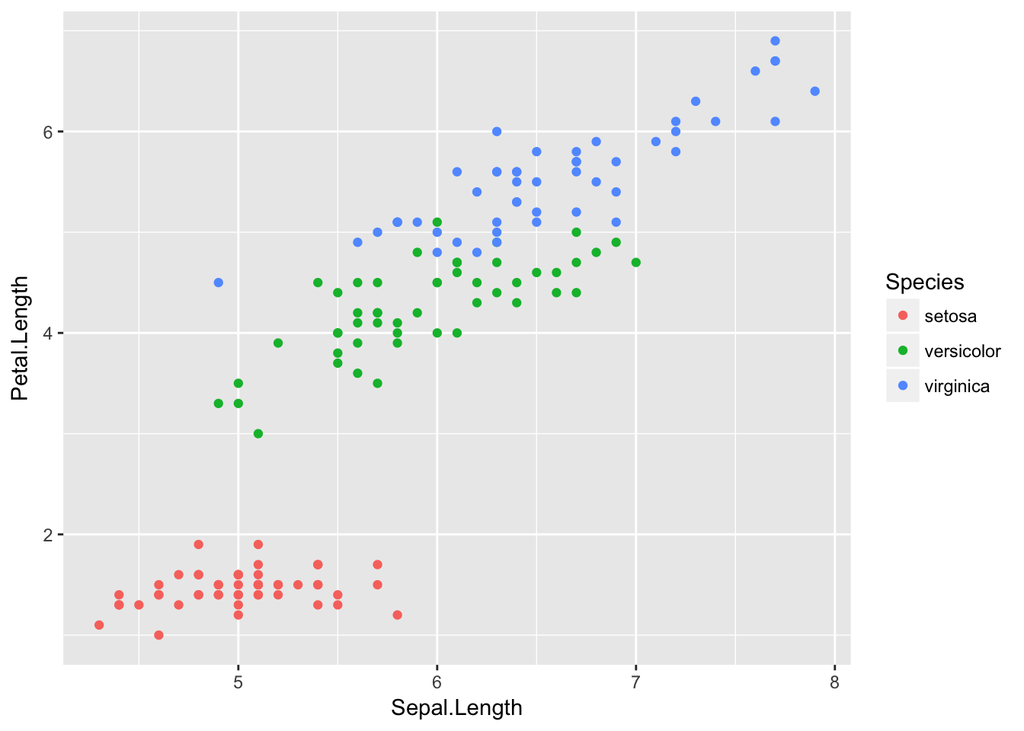

```r
ggplot(iris,aes(Sepal.Length,Petal.Length)) +
  geom_point(aes(color=Species))
```

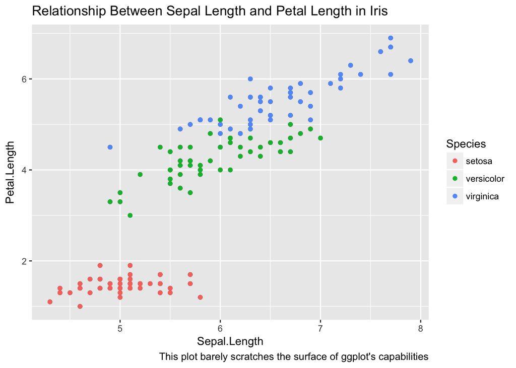

```r
pl4 <-pl3 +
  ggtitle("Relationship Between Sepal Length and Petal Length in Iris") +
  labs(caption="This plot barely scratches the surface of ggplot's capabilities")
pl4
```

# Piping - yes or no?

In the tidyverse, there is an alternative to writing expressions like

`function(x)`

which is supposed to be more like natural language. The above would be written

`x %>% function`

And again, “x” is the subject and “function” is the verb. And the utility of it is that if one wants to take the results of function (x) and apply it to function2, it would be written as

`x %>% function %>% function2`

Hadley Wickham has written a very good analogy, using the children’s rhyme about “Little Bunny Foo-Foo”

An example, done in both notations, would be

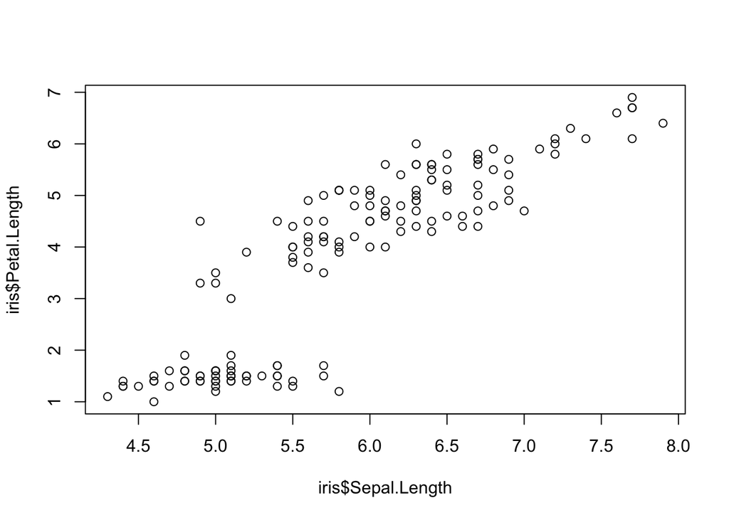

Plotting with standar notation

```r
plot(iris$Sepal.Length,iris$Petal.Length)
```

or, using pipes, we can write it more as a sentence like “from the iris data, select plot Sepal.Length on the x axis and Petal.Length on the y axis”

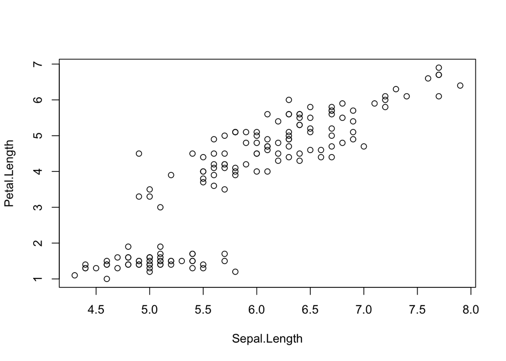

Plotting using pipe notation

```r
iris %>% select(Sepal.Length, Petal.Length) %>% plot
```

As you can see, the results are identical. So why one as opposed to the other? In truth, there may not be a good answer. The argument for piping is that it makes grammatical sense - go left to right from A to B to C. However, there are enough examples where it doesn’t work that make it problematical. For example, this traditional notation works:

```r
mean(iris$Sepal.Length)
```

```
## [1] 5.843333
```

But for esoteric reasons, the `mean` function does not work with pipe notation. So instead of writing

```r
iris %>% select(Sepal.Length) %>% mean
```

```
## [1] NA
```

One has to write

```r
iris %>% select(Sepal.Length) %>% colMeans
```

```
## Sepal.Length
##     5.843333
```

And there are other problems as well. So guess what? I’m not a super fan of piping as presently implemented, but anyone working with R needs to be aware of it, and at times, it is useful to make code compact and efficient.

# References

Tufte, Edward. 1983. “The visual display of quantitative information.” http://www.colorado.edu/UCB/AcademicAffairs/ArtsSciences/geography/foote/maps/assign/reading/TufteCoversheet.pdf.

Wickham, Hadley. 2009. *Ggplot2*. Springer US. doi:10.1007/978-0-387-98141-3.

———. 2010. “A Layered grammar of graphics.” *Journal of Computational and Graphical Statistics* 19 (1): 3–28. doi:10.1198/jcgs.2009.07098.